# Case Study 3 (unsupervised learning)

### Importing necessary libraries

```python
!pip install yellowbrick
```

```python
import numpy as np
import pandas as pd

import warnings

warnings.filterwarnings("ignore")

import matplotlib.pyplot as plt
import seaborn as sns

from sklearn.preprocessing import StandardScaler

from scipy.spatial.distance import cdist

from sklearn.cluster import KMeans
from sklearn.metrics import silhouette_score

from yellowbrick.cluster import KElbowVisualizer, SilhouetteVisualizer
```

```python
data=pd.read_csv("Loan_Customers.csv")
```

```python
df=data.copy()
```

```python
df.shape
```

```
(381, 13)
```

The dataset has 381 rows and 13 columns

```python
df.head()
```

|  | Loan_ID | Gender | Married | Dependents | Education | Self_Employed | ApplicantIncome | CoapplicantIncome | LoanAmount | Loan_Amount_Term | Credit_History | Property_Area | Loan_Status |
| --- | --- | --- | --- | --- | --- | --- | --- | --- | --- | --- | --- | --- | --- |
| 0 | LP001003 | Male | Yes | 1 | Graduate | No | 4583 | 1508.0 | 128.0 | 360.0 | 1.0 | Rural | N |
| 1 | LP001005 | Male | Yes | 0 | Graduate | Yes | 3000 | 0.0 | 66.0 | 360.0 | 1.0 | Urban | Y |
| 2 | LP001006 | Male | Yes | 0 | Not Graduate | No | 2583 | 2358.0 | 120.0 | 360.0 | 1.0 | Urban | Y |
| 3 | LP001008 | Male | No | 0 | Graduate | No | 6000 | 0.0 | 141.0 | 360.0 | 1.0 | Urban | Y |
| 4 | LP001013 | Male | Yes | 0 | Not Graduate | No | 2333 | 1516.0 | 95.0 | 360.0 | 1.0 | Urban | Y |

```python
df.sample(10,random_state=1)
```

|  | Loan_ID | Gender | Married | Dependents | Education | Self_Employed | ApplicantIncome | CoapplicantIncome | LoanAmount | Loan_Amount_Term | Credit_History | Property_Area | Loan_Status |
| --- | --- | --- | --- | --- | --- | --- | --- | --- | --- | --- | --- | --- | --- |
| 244 | LP002244 | Male | Yes | 0 | Graduate | No | 2333 | 2417.0 | 136.0 | 360.0 | 1.0 | Urban | Y |
| 180 | LP001926 | Male | Yes | 0 | Graduate | No | 3704 | 2000.0 | 120.0 | 360.0 | 1.0 | Rural | Y |
| 277 | LP002387 | Male | Yes | 0 | Graduate | No | 2425 | 2340.0 | 143.0 | 360.0 | 1.0 | Semiurban | Y |
| 185 | LP001945 | Female | No | NaN | Graduate | No | 5417 | 0.0 | 143.0 | 480.0 | 0.0 | Urban | N |
| 233 | LP002209 | Female | No | 0 | Graduate | NaN | 2764 | 1459.0 | 110.0 | 360.0 | 1.0 | Urban | Y |
| 314 | LP002587 | Male | Yes | 0 | Not Graduate | No | 2600 | 1700.0 | 107.0 | 360.0 | 1.0 | Rural | Y |
| 138 | LP001744 | Male | No | 0 | Graduate | No | 2971 | 2791.0 | 144.0 | 360.0 | 1.0 | Semiurban | Y |
| 201 | LP002035 | Male | Yes | 2 | Graduate | No | 3717 | 0.0 | 120.0 | 360.0 | 1.0 | Semiurban | Y |
| 117 | LP001664 | Male | No | 0 | Graduate | No | 4191 | 0.0 | 120.0 | 360.0 | 1.0 | Rural | Y |
| 301 | LP002517 | Male | Yes | 1 | Not Graduate | No | 2653 | 1500.0 | 113.0 | 180.0 | 0.0 | Rural | N |

```python
df.info()
```

```
<class 'pandas.core.frame.DataFrame'>
RangeIndex: 381 entries, 0 to 380
Data columns (total 13 columns):
 #   Column             Non-Null Count  Dtype
---  ------             --------------  -----
 0   Loan_ID            381 non-null    object
 1   Gender             376 non-null    object
 2   Married            381 non-null    object
 3   Dependents         373 non-null    object
 4   Education          381 non-null    object
 5   Self_Employed      360 non-null    object
 6   ApplicantIncome    381 non-null    int64
 7   CoapplicantIncome  381 non-null    float64
 8   LoanAmount         381 non-null    float64
 9   Loan_Amount_Term   370 non-null    float64
 10  Credit_History     351 non-null    float64
 11  Property_Area      381 non-null    object
 12  Loan_Status        381 non-null    object
dtypes: float64(4), int64(1), object(8)
memory usage: 38.8+ KB
```

As the Credit History column does not count as a numeric variable, there are only four numeric variables.

```python
df.isna().sum()
```

```
Loan_ID               0
Gender                5
Married               0
Dependents            8
Education             0
Self_Employed        21
ApplicantIncome       0
CoapplicantIncome     0
LoanAmount            0
Loan_Amount_Term     11
Credit_History       30
Property_Area         0
Loan_Status           0
dtype: int64
```

There are some missing values in the columns, but as long as they are not in the numeric columns is not a concern for us. So the only column that we should treat is Loan Amount Term.

```python
df.describe().T
```

|  | count | mean | std | min | 25% | 50% | 75% | max |
| --- | --- | --- | --- | --- | --- | --- | --- | --- |
| ApplicantIncome | 381.0 | 3579.845144 | 1419.813818 | 150.0 | 2600.0 | 3333.0 | 4288.0 | 9703.0 |
| CoapplicantIncome | 381.0 | 1277.275381 | 2340.818114 | 0.0 | 0.0 | 983.0 | 2016.0 | 33837.0 |
| LoanAmount | 381.0 | 104.986877 | 28.358464 | 9.0 | 90.0 | 110.0 | 127.0 | 150.0 |
| Loan_Amount_Term | 370.0 | 340.864865 | 68.549257 | 12.0 | 360.0 | 360.0 | 360.0 | 480.0 |
| Credit_History | 351.0 | 0.837607 | 0.369338 | 0.0 | 1.0 | 1.0 | 1.0 | 1.0 |

The mean applicant income is 3580, indicating that most clients have an average income. The loan amount term is 360 months for almost 75% of the customers. Due to the mean and max amount, there are some outliers in the columns.

```python
(df == 0).sum()
```

```
Loan_ID                0
Gender                 0
Married                0
Dependents             0
Education              0
Self_Employed          0
ApplicantIncome        0
CoapplicantIncome    175
LoanAmount             0
Loan_Amount_Term       0
Credit_History        57
Property_Area          0
Loan_Status            0
dtype: int64
```

There are some 0 amounts in the Co-applicant income column, but as they are in the column, that zero amount is feasible, and the Co-applicant income may be zero, so we do not consider them as missing values.

### Make a subset for numerical variables

```python
df.columns
```

```
Index(['Loan_ID', 'Gender', 'Married', 'Dependents', 'Education',
       'Self_Employed', 'ApplicantIncome', 'CoapplicantIncome', 'LoanAmount',
       'Loan_Amount_Term', 'Credit_History', 'Property_Area', 'Loan_Status'],
      dtype='object')
```

```python
df_num=df[['ApplicantIncome', 'CoapplicantIncome', 'LoanAmount',
       'Loan_Amount_Term']]
```

## EDA

### Univariate Analysis

```python
# function to plot a boxplot and a histogram along the same scale.


def histogram_boxplot(data, feature, figsize=(12, 7), kde=False, bins=None):
    """
    Boxplot and histogram combined

    data: dataframe
    feature: dataframe column
    figsize: size of figure (default (12,7))
    kde: whether to the show density curve (default False)
    bins: number of bins for histogram (default None)
    """
    f2, (ax_box2, ax_hist2) = plt.subplots(
        nrows=2,  # Number of rows of the subplot grid= 2
        sharex=True,  # x-axis will be shared among all subplots
        gridspec_kw={"height_ratios": (0.25, 0.75)},
        figsize=figsize,
    )  # creating the 2 subplots
    sns.boxplot(
        data=data, x=feature, ax=ax_box2, showmeans=True, color="violet"
    )  # boxplot will be created and a star will indicate the mean value of the column
    sns.histplot(
        data=data, x=feature, kde=kde, ax=ax_hist2, bins=bins, palette="winter"
    ) if bins else sns.histplot(
        data=data, x=feature, kde=kde, ax=ax_hist2
    )  # For histogram
    ax_hist2.axvline(
        data[feature].mean(), color="green", linestyle="--"
    )  # Add mean to the histogram
    ax_hist2.axvline(
        data[feature].median(), color="black", linestyle="-"
    )  # Add median to the histogram
```

```python
df_num.columns
```

```
Index(['ApplicantIncome', 'CoapplicantIncome', 'LoanAmount',
       'Loan_Amount_Term'],
      dtype='object')
```

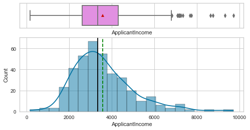

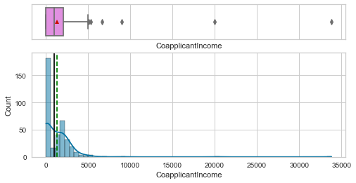

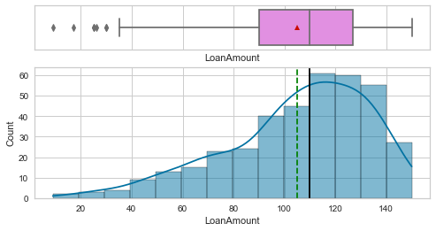

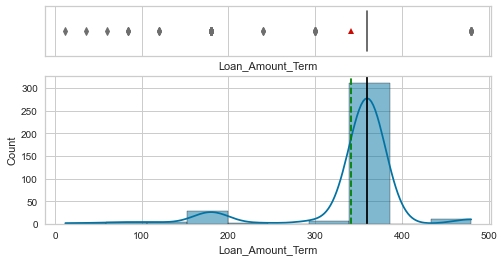

```python
for item in df_num:
    histogram_boxplot(df, item, kde=True, figsize=(8, 4))
```

Observations: Most of the applicants' incomes are approximately 2500 to 4000 while this decreases to almost zero to 2000 for Co-applicants'. The loan amount is 110-130 K for the majority of the customers. The loan term is 360-380 months, almost f0r 80% of the clients. There are some outliers in all the variables and because the k-means clustering is so sensitive to outliers they should be replaced by means.

### Replacing Outliers and Missing Values

```python
for x in ['CoapplicantIncome','ApplicantIncome','LoanAmount','Loan_Amount_Term']:
    q75,q25 = np.percentile(df_num.loc[:,x],[75,25])
    intr_qr = q75-q25

    max = q75+(1.5*intr_qr)
    min = q25-(1.5*intr_qr)

    df_num.loc[df_num[x] < min,x] = np.nan
    df_num.loc[df_num[x] > max,x] = np.nan
```

```python
df_num.isna().sum()
```

```
ApplicantIncome       6
CoapplicantIncome     2
LoanAmount            6
Loan_Amount_Term     69
dtype: int64
```

```python
df_num.fillna(df.mean(), inplace=True)
```

```python
df_num.isna().sum()
```

```
ApplicantIncome      0
CoapplicantIncome    0
LoanAmount           0
Loan_Amount_Term     0
dtype: int64
```

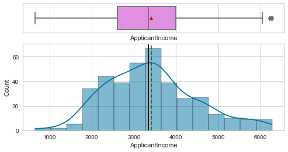

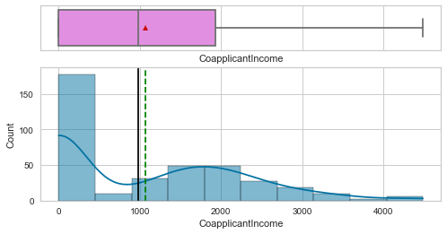

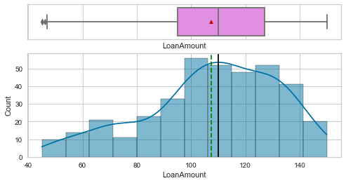

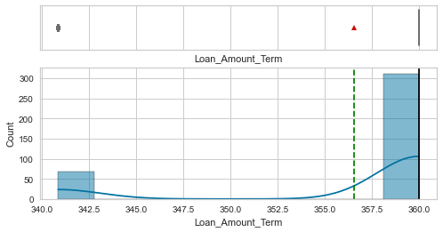

```python
for item in df_num:
    histogram_boxplot(df_num, item, kde=True, figsize=(8, 4))
```

### Bivariate Analsysis

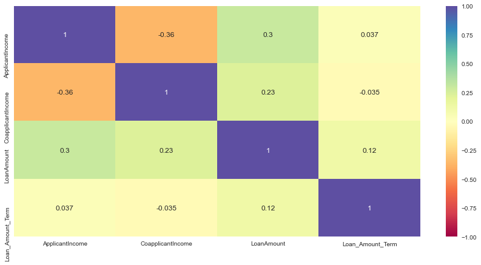

```python
plt.figure(figsize=(15,7))
sns.heatmap(df_num.corr(),annot=True,vmin=-1,vmax=1,cmap="Spectral")
plt.show()
```

Observation: There is no strong positive correlation between variables. There is a positive relationship between loan amount and applicant income which is not very high.

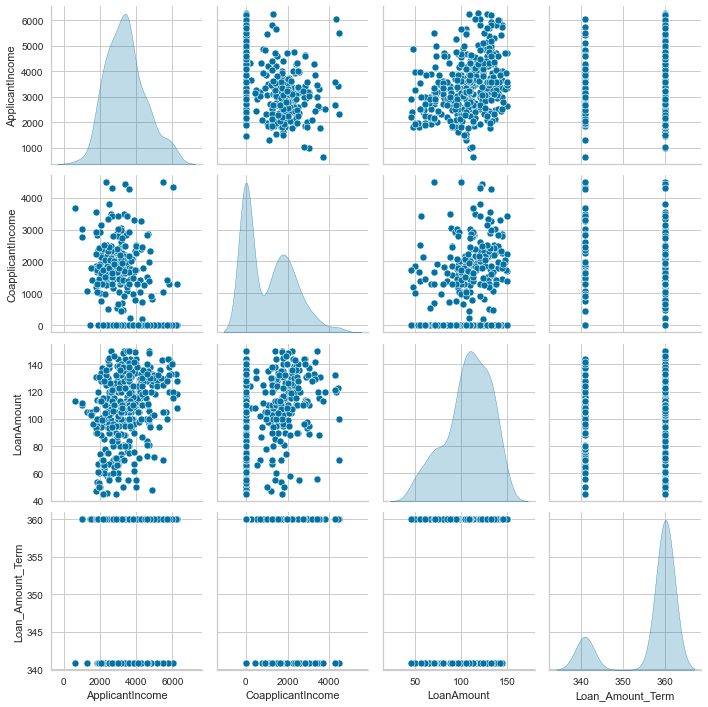

```python
sns.pairplot(data=df_num,diag_kind="kde")
plt.show()
```

Observation: Applicant Income is almost normally distributed. Distribution of Loan Amount, Loan Amount Term, and Co-applicant Income seem to be bimodal.

```python
scaler = StandardScaler()
subset = df_num.copy()
subset_scaled = scaler.fit_transform(subset)
```

```python
subset_scaled_df = pd.DataFrame(subset_scaled, columns=subset.columns)
```

```python
subset_scaled_df.head()
```

|  | ApplicantIncome | CoapplicantIncome | LoanAmount | Loan_Amount_Term |
| --- | --- | --- | --- | --- |
| 0 | 1.091904 | 0.380701 | 0.832727 | 0.47027 |
| 1 | -0.384138 | -0.924908 | -1.687161 | 0.47027 |
| 2 | -0.772963 | 1.116622 | 0.507580 | 0.47027 |
| 3 | 2.413162 | -0.924908 | 1.361090 | 0.47027 |
| 4 | -1.006071 | 0.387628 | -0.508504 | 0.47027 |

```python
model= KMeans(n_clusters=5)
model.fit(subset_scaled_df)
```

```
KMeans(n_clusters=5)
```

### Elbow Curve

```
Number of Clusters: 1 	Average Distortion: 1.8790962569467657
Number of Clusters: 2 	Average Distortion: 1.5643770076909131
Number of Clusters: 3 	Average Distortion: 1.3051598163056222
Number of Clusters: 4 	Average Distortion: 1.1294664322560453
Number of Clusters: 5 	Average Distortion: 1.0699516945953447
Number of Clusters: 6 	Average Distortion: 0.9849526267731715
Number of Clusters: 7 	Average Distortion: 0.9085893329401951
Number of Clusters: 8 	Average Distortion: 0.868965689798333
```

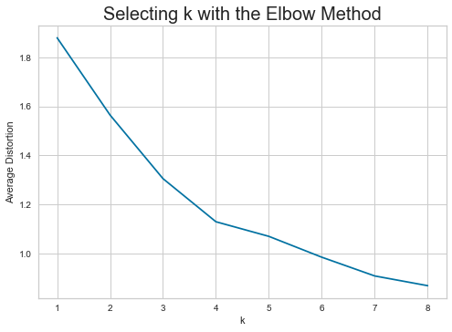

```python
clusters = range(1, 9)
meanDistortions = []

for k in clusters:
    model = KMeans(n_clusters=k)
    model.fit(subset_scaled_df)
    prediction = model.predict(subset_scaled_df)
    distortion = (
        sum(
            np.min(cdist(subset_scaled_df, model.cluster_centers_, "euclidean"), axis=1)
        )
        / subset_scaled_df.shape[0]
    )

    meanDistortions.append(distortion)

    print("Number of Clusters:", k, "\tAverage Distortion:", distortion)

plt.plot(clusters, meanDistortions, "bx-")
plt.xlabel("k")
plt.ylabel("Average Distortion")
plt.title("Selecting k with the Elbow Method", fontsize=20)
```

The appropriate value of k from the elbow curve seems to be 4, 5 or 6.

### Silhouette scores

```
For n_clusters = 2, silhouette score is 0.27656622845351697
For n_clusters = 3, silhouette score is 0.3398948084343723
For n_clusters = 4, silhouette score is 0.354350689511962
For n_clusters = 5, silhouette score is 0.3648159810401499
For n_clusters = 6, silhouette score is 0.33263333871296163
For n_clusters = 7, silhouette score is 0.3253176243415641
For n_clusters = 8, silhouette score is 0.3185207149962415
For n_clusters = 9, silhouette score is 0.31591921228267483
```

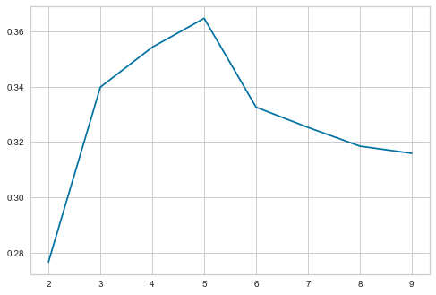

```python
sil_score = []
cluster_list = list(range(2, 10))
for n_clusters in cluster_list:
    clusterer = KMeans(n_clusters=n_clusters)
    preds = clusterer.fit_predict((subset_scaled_df))
    # centers = clusterer.cluster_centers_
    score = silhouette_score(subset_scaled_df, preds)
    sil_score.append(score)
    print("For n_clusters = {}, silhouette score is {}".format(n_clusters, score))

plt.plot(cluster_list, sil_score)
```

From the silhouette scores, it seems that 5 is a good value of k.

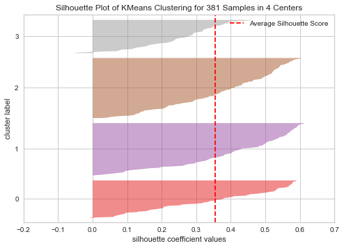

```python
# finding optimal no. of clusters with silhouette coefficients
visualizer = SilhouetteVisualizer(KMeans(4, random_state=1))
visualizer.fit(subset_scaled_df)
visualizer.show()
```

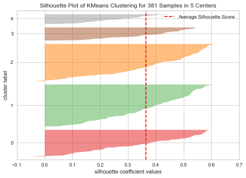

```python
# finding optimal no. of clusters with silhouette coefficients
visualizer = SilhouetteVisualizer(KMeans(5, random_state=1))
visualizer.fit(subset_scaled_df)
visualizer.show()
```

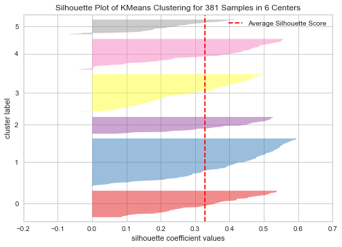

```python
# finding optimal no. of clusters with silhouette coefficients
visualizer = SilhouetteVisualizer(KMeans(6, random_state=1))
visualizer.fit(subset_scaled_df)
visualizer.show()
```

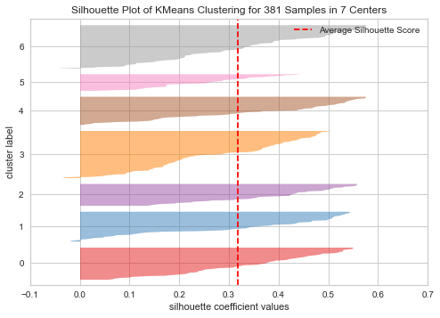

```python
# finding optimal no. of clusters with silhouette coefficients
visualizer = SilhouetteVisualizer(KMeans(7, random_state=1))
visualizer.fit(subset_scaled_df)
visualizer.show()
```

```python
kmeans = KMeans(n_clusters=4, random_state=0)
kmeans.fit(subset_scaled_df)
```

```
KMeans(n_clusters=4, random_state=0)
```

```python
df["K_means_segments"] = kmeans.labels_
```

```python
cluster_profile = df.groupby("K_means_segments").mean()
```

```python
df.head(10)
```

|  | Loan_ID | Gender | Married | Dependents | Education | Self_Employed | ApplicantIncome | CoapplicantIncome | LoanAmount | Loan_Amount_Term | Credit_History | Property_Area | Loan_Status | K_means_segments |
| --- | --- | --- | --- | --- | --- | --- | --- | --- | --- | --- | --- | --- | --- | --- |
| 0 | LP001003 | Male | Yes | 1 | Graduate | No | 4583 | 1508.0 | 128.0 | 360.0 | 1.0 | Rural | N | 1 |
| 1 | LP001005 | Male | Yes | 0 | Graduate | Yes | 3000 | 0.0 | 66.0 | 360.0 | 1.0 | Urban | Y | 3 |
| 2 | LP001006 | Male | Yes | 0 | Not Graduate | No | 2583 | 2358.0 | 120.0 | 360.0 | 1.0 | Urban | Y | 2 |
| 3 | LP001008 | Male | No | 0 | Graduate | No | 6000 | 0.0 | 141.0 | 360.0 | 1.0 | Urban | Y | 1 |
| 4 | LP001013 | Male | Yes | 0 | Not Graduate | No | 2333 | 1516.0 | 95.0 | 360.0 | 1.0 | Urban | Y | 2 |
| 5 | LP001024 | Male | Yes | 2 | Graduate | No | 3200 | 700.0 | 70.0 | 360.0 | 1.0 | Urban | Y | 3 |
| 6 | LP001027 | Male | Yes | 2 | Graduate | NaN | 2500 | 1840.0 | 109.0 | 360.0 | 1.0 | Urban | Y | 2 |
| 7 | LP001029 | Male | No | 0 | Graduate | No | 1853 | 2840.0 | 114.0 | 360.0 | 1.0 | Rural | N | 2 |
| 8 | LP001030 | Male | Yes | 2 | Graduate | No | 1299 | 1086.0 | 17.0 | 120.0 | 1.0 | Urban | Y | 0 |
| 9 | LP001032 | Male | No | 0 | Graduate | No | 4950 | 0.0 | 125.0 | 360.0 | 1.0 | Urban | Y | 1 |

```python
cluster_profile["count_in_each_segment"] = (
   df.groupby("K_means_segments")["ApplicantIncome"].count().values
)
```

```python
cluster_profile.style.highlight_max(color="lightgreen", axis=0)
```

| K_means_segments | ApplicantIncome | CoapplicantIncome | LoanAmount | Loan_Amount_Term | Credit_History | count_in_each_segment |
| --- | --- | --- | --- | --- | --- | --- |
| 0 | 3620.173913 | 1233.359420 | 95.927536 | 237.931034 | 0.734375 | 69 |
| 1 | 4886.055046 | 263.513761 | 116.990826 | 360.000000 | 0.861386 | 109 |
| 2 | 2836.352000 | 2422.856000 | 119.040000 | 360.000000 | 0.837607 | 125 |
| 3 | 2910.320513 | 896.924615 | 73.705128 | 360.000000 | 0.898551 | 78 |

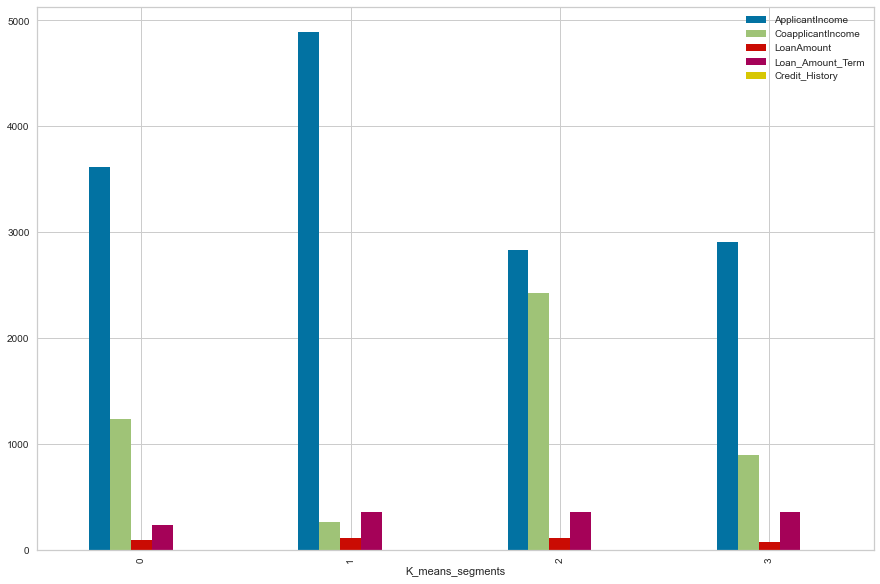

```python
df.groupby("K_means_segments").mean().plot.bar(figsize=(15, 10))
```

### Insights

##### Cluster 0:

Applicants' incomes are a bit more than average, and Co-applicants' incomes are average. Loan amount is moderate. Loan amount term is the lowest. It is the smallest group.

##### Cluster 1:

Applicants' incomes is the highest while the Co-applicants' incomes is the lowest. Loan amount is high. Loan amount term is exactly the same as the other two clusters(2 and 3).

#### Cluster 2:

Applicants' incomes and the Co-applicants' incomes are moderate and have almost similar amounts. Loan amount is the highest. Loan amount term is exactly the same as the other two clusters(1 and 3). It is the biggest cluster.

#### Cluster 3:

Applicants' incomes is moderate and the Co-applicants' incomes is low. Loan amount is the lowest. Loan amount term is exactly the same as the other two clusters(1 and 2).

### Business Recommendations

#### Cluster 3: This group includes clients with the lowest amount of loans. Their income is moderate, and their co-applicants income is low. Their number is not very much either. This group is high risk because neither the applicant nor the co-applicant has a high income and might be a defaulter.